# Risk Factor Analysis

## Outcome Variable

**Outcome Variable:** swasted

## Predictor Variables

**Intervention Variable:** hhwealth_quart

**Adjustment Set:**

unadjusted

## Stratifying Variables

The analysis was stratified on these variable(s):

- agecat
- studyid
- country

## Data Summary

| agecat | studyid | country | hhwealth_quart | swasted | n_cell | n |
| --- | --- | --- | --- | --- | --- | --- |
| Birth | ki0047075b-MAL-ED | BANGLADESH | Wealth Q4 | 0 | 21 | 76 |
| Birth | ki0047075b-MAL-ED | BANGLADESH | Wealth Q4 | 1 | 0 | 76 |
| Birth | ki0047075b-MAL-ED | BANGLADESH | Wealth Q1 | 0 | 17 | 76 |
| Birth | ki0047075b-MAL-ED | BANGLADESH | Wealth Q1 | 1 | 0 | 76 |
| Birth | ki0047075b-MAL-ED | BANGLADESH | Wealth Q2 | 0 | 16 | 76 |
| Birth | ki0047075b-MAL-ED | BANGLADESH | Wealth Q2 | 1 | 2 | 76 |
| Birth | ki0047075b-MAL-ED | BANGLADESH | Wealth Q3 | 0 | 20 | 76 |
| Birth | ki0047075b-MAL-ED | BANGLADESH | Wealth Q3 | 1 | 0 | 76 |
| Birth | ki0047075b-MAL-ED | INDIA | Wealth Q4 | 0 | 11 | 54 |
| Birth | ki0047075b-MAL-ED | INDIA | Wealth Q4 | 1 | 0 | 54 |
| Birth | ki0047075b-MAL-ED | INDIA | Wealth Q1 | 0 | 14 | 54 |
| Birth | ki0047075b-MAL-ED | INDIA | Wealth Q1 | 1 | 3 | 54 |
| Birth | ki0047075b-MAL-ED | INDIA | Wealth Q2 | 0 | 15 | 54 |
| Birth | ki0047075b-MAL-ED | INDIA | Wealth Q2 | 1 | 0 | 54 |
| Birth | ki0047075b-MAL-ED | INDIA | Wealth Q3 | 0 | 11 | 54 |
| Birth | ki0047075b-MAL-ED | INDIA | Wealth Q3 | 1 | 0 | 54 |
| Birth | ki0047075b-MAL-ED | NEPAL | Wealth Q4 | 0 | 9 | 30 |
| Birth | ki0047075b-MAL-ED | NEPAL | Wealth Q4 | 1 | 0 | 30 |
| Birth | ki0047075b-MAL-ED | NEPAL | Wealth Q1 | 0 | 8 | 30 |
| Birth | ki0047075b-MAL-ED | NEPAL | Wealth Q1 | 1 | 0 | 30 |
| Birth | ki0047075b-MAL-ED | NEPAL | Wealth Q2 | 0 | 5 | 30 |
| Birth | ki0047075b-MAL-ED | NEPAL | Wealth Q2 | 1 | 1 | 30 |
| Birth | ki0047075b-MAL-ED | NEPAL | Wealth Q3 | 0 | 7 | 30 |
| Birth | ki0047075b-MAL-ED | NEPAL | Wealth Q3 | 1 | 0 | 30 |
| Birth | ki0047075b-MAL-ED | PERU | Wealth Q4 | 0 | 10 | 36 |
| Birth | ki0047075b-MAL-ED | PERU | Wealth Q4 | 1 | 0 | 36 |
| Birth | ki0047075b-MAL-ED | PERU | Wealth Q1 | 0 | 9 | 36 |
| Birth | ki0047075b-MAL-ED | PERU | Wealth Q1 | 1 | 0 | 36 |
| Birth | ki0047075b-MAL-ED | PERU | Wealth Q2 | 0 | 9 | 36 |
| Birth | ki0047075b-MAL-ED | PERU | Wealth Q2 | 1 | 0 | 36 |

[output cut: 346 more lines]

The following strata were considered:

- agecat: 24 months, studyid: ki0047075b-MAL-ED, country: BANGLADESH
- agecat: 24 months, studyid: ki0047075b-MAL-ED, country: INDIA
- agecat: 24 months, studyid: ki0047075b-MAL-ED, country: NEPAL
- agecat: 24 months, studyid: ki0047075b-MAL-ED, country: PERU
- agecat: 24 months, studyid: ki0047075b-MAL-ED, country: SOUTH AFRICA
- agecat: 24 months, studyid: ki0047075b-MAL-ED, country: TANZANIA, UNITED REPUBLIC OF
- agecat: 24 months, studyid: ki1000108-CMC-V-BCS-2002, country: INDIA
- agecat: 24 months, studyid: ki1000108-IRC, country: INDIA
- agecat: 24 months, studyid: ki1017093b-PROVIDE, country: BANGLADESH
- agecat: 24 months, studyid: ki1066203-TanzaniaChild2, country: TANZANIA, UNITED REPUBLIC OF
- agecat: 24 months, studyid: ki1113344-GMS-Nepal, country: NEPAL
- agecat: 24 months, studyid: ki1114097-CONTENT, country: PERU
- agecat: 24 months, studyid: ki1135781-COHORTS, country: GUATEMALA
- agecat: 24 months, studyid: ki1135781-COHORTS, country: PHILIPPINES
- agecat: 24 months, studyid: ki1148112-LCNI-5, country: MALAWI
- agecat: 24 months, studyid: kiGH5241-JiVitA-3, country: BANGLADESH
- agecat: 24 months, studyid: kiGH5241-JiVitA-4, country: BANGLADESH
- agecat: 6 months, studyid: ki0047075b-MAL-ED, country: BANGLADESH
- agecat: 6 months, studyid: ki0047075b-MAL-ED, country: INDIA
- agecat: 6 months, studyid: ki0047075b-MAL-ED, country: NEPAL
- agecat: 6 months, studyid: ki0047075b-MAL-ED, country: PERU
- agecat: 6 months, studyid: ki0047075b-MAL-ED, country: SOUTH AFRICA
- agecat: 6 months, studyid: ki0047075b-MAL-ED, country: TANZANIA, UNITED REPUBLIC OF
- agecat: 6 months, studyid: ki1000108-CMC-V-BCS-2002, country: INDIA
- agecat: 6 months, studyid: ki1000108-IRC, country: INDIA
- agecat: 6 months, studyid: ki1017093b-PROVIDE, country: BANGLADESH
- agecat: 6 months, studyid: ki1066203-TanzaniaChild2, country: TANZANIA, UNITED REPUBLIC OF
- agecat: 6 months, studyid: ki1113344-GMS-Nepal, country: NEPAL
- agecat: 6 months, studyid: ki1114097-CONTENT, country: PERU
- agecat: 6 months, studyid: ki1135781-COHORTS, country: GUATEMALA
- agecat: 6 months, studyid: ki1135781-COHORTS, country: PHILIPPINES
- agecat: 6 months, studyid: ki1148112-LCNI-5, country: MALAWI
- agecat: 6 months, studyid: kiGH5241-JiVitA-3, country: BANGLADESH
- agecat: 6 months, studyid: kiGH5241-JiVitA-4, country: BANGLADESH
- agecat: Birth, studyid: ki0047075b-MAL-ED, country: BANGLADESH
- agecat: Birth, studyid: ki0047075b-MAL-ED, country: INDIA
- agecat: Birth, studyid: ki0047075b-MAL-ED, country: NEPAL
- agecat: Birth, studyid: ki0047075b-MAL-ED, country: PERU
- agecat: Birth, studyid: ki0047075b-MAL-ED, country: SOUTH AFRICA
- agecat: Birth, studyid: ki0047075b-MAL-ED, country: TANZANIA, UNITED REPUBLIC OF
- agecat: Birth, studyid: ki1000108-CMC-V-BCS-2002, country: INDIA
- agecat: Birth, studyid: ki1000108-IRC, country: INDIA
- agecat: Birth, studyid: ki1114097-CONTENT, country: PERU
- agecat: Birth, studyid: ki1135781-COHORTS, country: GUATEMALA
- agecat: Birth, studyid: ki1135781-COHORTS, country: PHILIPPINES
- agecat: Birth, studyid: kiGH5241-JiVitA-3, country: BANGLADESH
- agecat: Birth, studyid: kiGH5241-JiVitA-4, country: BANGLADESH

### Dropped Strata

Some strata were dropped due to rare outcomes:

- agecat: Birth, studyid: ki0047075b-MAL-ED, country: BANGLADESH
- agecat: Birth, studyid: ki0047075b-MAL-ED, country: INDIA
- agecat: Birth, studyid: ki0047075b-MAL-ED, country: NEPAL
- agecat: Birth, studyid: ki0047075b-MAL-ED, country: PERU
- agecat: Birth, studyid: ki0047075b-MAL-ED, country: SOUTH AFRICA
- agecat: Birth, studyid: ki0047075b-MAL-ED, country: TANZANIA, UNITED REPUBLIC OF
- agecat: Birth, studyid: ki1000108-CMC-V-BCS-2002, country: INDIA
- agecat: Birth, studyid: ki1114097-CONTENT, country: PERU
- agecat: Birth, studyid: kiGH5241-JiVitA-4, country: BANGLADESH
- agecat: 6 months, studyid: ki0047075b-MAL-ED, country: BANGLADESH
- agecat: 6 months, studyid: ki0047075b-MAL-ED, country: INDIA
- agecat: 6 months, studyid: ki0047075b-MAL-ED, country: NEPAL
- agecat: 6 months, studyid: ki0047075b-MAL-ED, country: PERU
- agecat: 6 months, studyid: ki0047075b-MAL-ED, country: SOUTH AFRICA
- agecat: 6 months, studyid: ki0047075b-MAL-ED, country: TANZANIA, UNITED REPUBLIC OF
- agecat: 6 months, studyid: ki1000108-CMC-V-BCS-2002, country: INDIA
- agecat: 6 months, studyid: ki1000108-IRC, country: INDIA
- agecat: 6 months, studyid: ki1017093b-PROVIDE, country: BANGLADESH
- agecat: 6 months, studyid: ki1066203-TanzaniaChild2, country: TANZANIA, UNITED REPUBLIC OF
- agecat: 6 months, studyid: ki1113344-GMS-Nepal, country: NEPAL
- agecat: 6 months, studyid: ki1114097-CONTENT, country: PERU
- agecat: 6 months, studyid: ki1135781-COHORTS, country: GUATEMALA
- agecat: 6 months, studyid: ki1148112-LCNI-5, country: MALAWI
- agecat: 24 months, studyid: ki0047075b-MAL-ED, country: BANGLADESH
- agecat: 24 months, studyid: ki0047075b-MAL-ED, country: INDIA
- agecat: 24 months, studyid: ki0047075b-MAL-ED, country: NEPAL
- agecat: 24 months, studyid: ki0047075b-MAL-ED, country: PERU
- agecat: 24 months, studyid: ki0047075b-MAL-ED, country: SOUTH AFRICA
- agecat: 24 months, studyid: ki0047075b-MAL-ED, country: TANZANIA, UNITED REPUBLIC OF
- agecat: 24 months, studyid: ki1000108-CMC-V-BCS-2002, country: INDIA
- agecat: 24 months, studyid: ki1000108-IRC, country: INDIA
- agecat: 24 months, studyid: ki1017093b-PROVIDE, country: BANGLADESH
- agecat: 24 months, studyid: ki1066203-TanzaniaChild2, country: TANZANIA, UNITED REPUBLIC OF
- agecat: 24 months, studyid: ki1114097-CONTENT, country: PERU
- agecat: 24 months, studyid: ki1135781-COHORTS, country: GUATEMALA
- agecat: 24 months, studyid: ki1135781-COHORTS, country: PHILIPPINES
- agecat: 24 months, studyid: ki1148112-LCNI-5, country: MALAWI

## Methods Detail

We’re interested in the causal parameters $E[Y_a]$ for all values of $a \in \mathcal{A}$. These parameters represent the mean outcome if, possibly contrary to fact, we intervened to set all units to have $A=a$. Under the randomization and positivity assumptions, these are identified by the statistical parameters $\psi_a=E_W[E_{Y|A,W}(Y|A=a,W)]$. In addition, we’re interested in the mean of $Y$, $E[Y]$ under no intervention (the observed mean). We will estimate these parameters by using SuperLearner to fit the relevant likelihood factors – $E_{Y|A,W}(Y|A=a,W)$ and $p(A=a|W)$, and then updating our likelihood fit using a joint TMLE.

For unadjusted analyses ($W=\{\}$), initial likelihoods were estimated using Lrnr_glm to estimate the simple $E(Y|A)$ and Lrnr_mean to estimate $p(A)$. For adjusted analyses, a small library containing Lrnr_glmnet, Lrnr_xgboost, and Lrnr_mean was used.

Having estimated these parameters, we will then use the delta method to estimate relative risks and attributable risks relative to a prespecified baseline level of $A$.

# Results Detail

## Results Plots

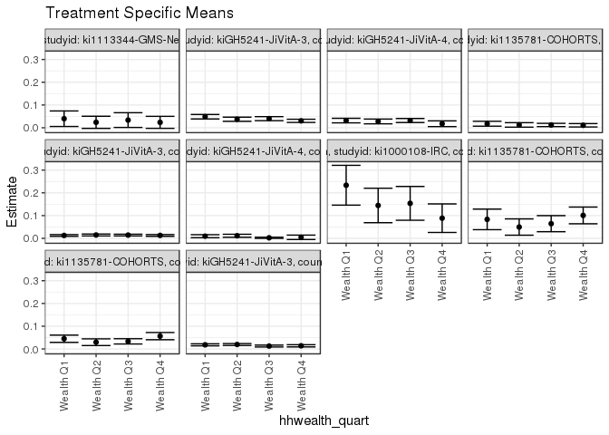

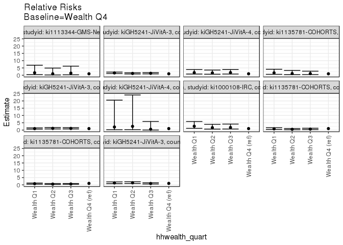

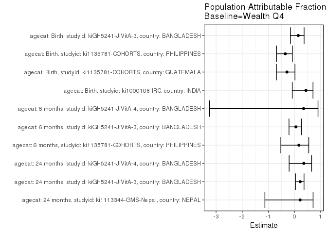

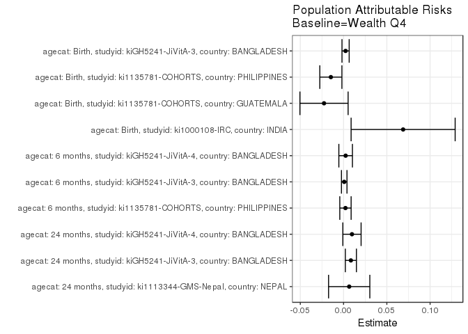

## Results Table

### Parameter: TSM

| agecat | studyid | country | intervention_level | baseline_level | estimate | ci_lower | ci_upper |
| --- | --- | --- | --- | --- | --- | --- | --- |
| Birth | ki1000108-IRC | INDIA | Wealth Q4 | NA | 0.0886076 | 0.0258514 | 0.1513638 |
| Birth | ki1000108-IRC | INDIA | Wealth Q1 | NA | 0.2333333 | 0.1458244 | 0.3208423 |
| Birth | ki1000108-IRC | INDIA | Wealth Q2 | NA | 0.1445783 | 0.0688105 | 0.2203461 |
| Birth | ki1000108-IRC | INDIA | Wealth Q3 | NA | 0.1538462 | 0.0796076 | 0.2280847 |
| Birth | ki1135781-COHORTS | GUATEMALA | Wealth Q4 | NA | 0.1007752 | 0.0640176 | 0.1375328 |
| Birth | ki1135781-COHORTS | GUATEMALA | Wealth Q1 | NA | 0.0833333 | 0.0381602 | 0.1285064 |
| Birth | ki1135781-COHORTS | GUATEMALA | Wealth Q2 | NA | 0.0496454 | 0.0137682 | 0.0855226 |
| Birth | ki1135781-COHORTS | GUATEMALA | Wealth Q3 | NA | 0.0645161 | 0.0291863 | 0.0998460 |
| Birth | ki1135781-COHORTS | PHILIPPINES | Wealth Q4 | NA | 0.0564417 | 0.0405954 | 0.0722880 |
| Birth | ki1135781-COHORTS | PHILIPPINES | Wealth Q1 | NA | 0.0448223 | 0.0288760 | 0.0607686 |
| Birth | ki1135781-COHORTS | PHILIPPINES | Wealth Q2 | NA | 0.0296443 | 0.0148640 | 0.0444246 |
| Birth | ki1135781-COHORTS | PHILIPPINES | Wealth Q3 | NA | 0.0333333 | 0.0217946 | 0.0448721 |
| Birth | kiGH5241-JiVitA-3 | BANGLADESH | Wealth Q4 | NA | 0.0138614 | 0.0090057 | 0.0187171 |
| Birth | kiGH5241-JiVitA-3 | BANGLADESH | Wealth Q1 | NA | 0.0181452 | 0.0137152 | 0.0225751 |
| Birth | kiGH5241-JiVitA-3 | BANGLADESH | Wealth Q2 | NA | 0.0195202 | 0.0152819 | 0.0237586 |
| Birth | kiGH5241-JiVitA-3 | BANGLADESH | Wealth Q3 | NA | 0.0127033 | 0.0084717 | 0.0169348 |
| 6 months | ki1135781-COHORTS | PHILIPPINES | Wealth Q4 | NA | 0.0107527 | 0.0033404 | 0.0181650 |
| 6 months | ki1135781-COHORTS | PHILIPPINES | Wealth Q1 | NA | 0.0175747 | 0.0067761 | 0.0283733 |
| 6 months | ki1135781-COHORTS | PHILIPPINES | Wealth Q2 | NA | 0.0123711 | 0.0025319 | 0.0222103 |
| 6 months | ki1135781-COHORTS | PHILIPPINES | Wealth Q3 | NA | 0.0121145 | 0.0049976 | 0.0192315 |
| 6 months | kiGH5241-JiVitA-3 | BANGLADESH | Wealth Q4 | NA | 0.0129169 | 0.0090078 | 0.0168259 |
| 6 months | kiGH5241-JiVitA-3 | BANGLADESH | Wealth Q1 | NA | 0.0127216 | 0.0088240 | 0.0166192 |
| 6 months | kiGH5241-JiVitA-3 | BANGLADESH | Wealth Q2 | NA | 0.0147077 | 0.0104893 | 0.0189260 |
| 6 months | kiGH5241-JiVitA-3 | BANGLADESH | Wealth Q3 | NA | 0.0143232 | 0.0105127 | 0.0181338 |
| 6 months | kiGH5241-JiVitA-4 | BANGLADESH | Wealth Q4 | NA | 0.0044903 | -0.0052639 | 0.0142446 |
| 6 months | kiGH5241-JiVitA-4 | BANGLADESH | Wealth Q1 | NA | 0.0093857 | 0.0028030 | 0.0159683 |
| 6 months | kiGH5241-JiVitA-4 | BANGLADESH | Wealth Q2 | NA | 0.0113636 | 0.0047581 | 0.0179692 |
| 6 months | kiGH5241-JiVitA-4 | BANGLADESH | Wealth Q3 | NA | 0.0024019 | -0.0000363 | 0.0048401 |
| 24 months | ki1113344-GMS-Nepal | NEPAL | Wealth Q4 | NA | 0.0236220 | -0.0028173 | 0.0500614 |
| 24 months | ki1113344-GMS-Nepal | NEPAL | Wealth Q1 | NA | 0.0396825 | 0.0055627 | 0.0738023 |
| 24 months | ki1113344-GMS-Nepal | NEPAL | Wealth Q2 | NA | 0.0238095 | -0.0028371 | 0.0504561 |
| 24 months | ki1113344-GMS-Nepal | NEPAL | Wealth Q3 | NA | 0.0336134 | 0.0011987 | 0.0660282 |
| 24 months | kiGH5241-JiVitA-3 | BANGLADESH | Wealth Q4 | NA | 0.0303305 | 0.0233688 | 0.0372922 |
| 24 months | kiGH5241-JiVitA-3 | BANGLADESH | Wealth Q1 | NA | 0.0483751 | 0.0385478 | 0.0582024 |
| 24 months | kiGH5241-JiVitA-3 | BANGLADESH | Wealth Q2 | NA | 0.0373491 | 0.0282011 | 0.0464971 |
| 24 months | kiGH5241-JiVitA-3 | BANGLADESH | Wealth Q3 | NA | 0.0399072 | 0.0310339 | 0.0487805 |
| 24 months | kiGH5241-JiVitA-4 | BANGLADESH | Wealth Q4 | NA | 0.0175834 | 0.0050329 | 0.0301340 |
| 24 months | kiGH5241-JiVitA-4 | BANGLADESH | Wealth Q1 | NA | 0.0314159 | 0.0213822 | 0.0414497 |
| 24 months | kiGH5241-JiVitA-4 | BANGLADESH | Wealth Q2 | NA | 0.0277289 | 0.0172434 | 0.0382143 |
| 24 months | kiGH5241-JiVitA-4 | BANGLADESH | Wealth Q3 | NA | 0.0317652 | 0.0228754 | 0.0406549 |

### Parameter: E(Y)

| agecat | studyid | country | intervention_level | baseline_level | estimate | ci_lower | ci_upper |
| --- | --- | --- | --- | --- | --- | --- | --- |
| Birth | ki1000108-IRC | INDIA | NA | NA | 0.1574344 | 0.1188345 | 0.1960344 |
| Birth | ki1135781-COHORTS | GUATEMALA | NA | NA | 0.0781893 | 0.0586874 | 0.0976912 |
| Birth | ki1135781-COHORTS | PHILIPPINES | NA | NA | 0.0417529 | 0.0344692 | 0.0490367 |
| Birth | kiGH5241-JiVitA-3 | BANGLADESH | NA | NA | 0.0161876 | 0.0138223 | 0.0185529 |
| 6 months | ki1135781-COHORTS | PHILIPPINES | NA | NA | 0.0129342 | 0.0086762 | 0.0171922 |
| 6 months | kiGH5241-JiVitA-3 | BANGLADESH | NA | NA | 0.0136688 | 0.0115917 | 0.0157459 |
| 6 months | kiGH5241-JiVitA-4 | BANGLADESH | NA | NA | 0.0068819 | 0.0035739 | 0.0101900 |
| 24 months | ki1113344-GMS-Nepal | NEPAL | NA | NA | 0.0301205 | 0.0150939 | 0.0451470 |
| 24 months | kiGH5241-JiVitA-3 | BANGLADESH | NA | NA | 0.0387755 | 0.0344469 | 0.0431042 |
| 24 months | kiGH5241-JiVitA-4 | BANGLADESH | NA | NA | 0.0272816 | 0.0219894 | 0.0325738 |

### Parameter: RR

| agecat | studyid | country | intervention_level | baseline_level | estimate | ci_lower | ci_upper |
| --- | --- | --- | --- | --- | --- | --- | --- |
| Birth | ki1000108-IRC | INDIA | Wealth Q4 | Wealth Q4 | 1.0000000 | 1.0000000 | 1.0000000 |
| Birth | ki1000108-IRC | INDIA | Wealth Q1 | Wealth Q4 | 2.6333330 | 1.1815568 | 5.8689030 |
| Birth | ki1000108-IRC | INDIA | Wealth Q2 | Wealth Q4 | 1.6316693 | 0.6760758 | 3.9379384 |
| Birth | ki1000108-IRC | INDIA | Wealth Q3 | Wealth Q4 | 1.7362635 | 0.7369189 | 4.0908314 |
| Birth | ki1135781-COHORTS | GUATEMALA | Wealth Q4 | Wealth Q4 | 1.0000000 | 1.0000000 | 1.0000000 |
| Birth | ki1135781-COHORTS | GUATEMALA | Wealth Q1 | Wealth Q4 | 0.8269231 | 0.4302403 | 1.5893484 |
| Birth | ki1135781-COHORTS | GUATEMALA | Wealth Q2 | Wealth Q4 | 0.4926350 | 0.2192618 | 1.1068468 |
| Birth | ki1135781-COHORTS | GUATEMALA | Wealth Q3 | Wealth Q4 | 0.6401985 | 0.3315606 | 1.2361364 |
| Birth | ki1135781-COHORTS | PHILIPPINES | Wealth Q4 | Wealth Q4 | 1.0000000 | 1.0000000 | 1.0000000 |
| Birth | ki1135781-COHORTS | PHILIPPINES | Wealth Q1 | Wealth Q4 | 0.7941335 | 0.5047419 | 1.2494464 |
| Birth | ki1135781-COHORTS | PHILIPPINES | Wealth Q2 | Wealth Q4 | 0.5252191 | 0.2963715 | 0.9307748 |
| Birth | ki1135781-COHORTS | PHILIPPINES | Wealth Q3 | Wealth Q4 | 0.5905797 | 0.3781913 | 0.9222433 |
| Birth | kiGH5241-JiVitA-3 | BANGLADESH | Wealth Q4 | Wealth Q4 | 1.0000000 | 1.0000000 | 1.0000000 |
| Birth | kiGH5241-JiVitA-3 | BANGLADESH | Wealth Q1 | Wealth Q4 | 1.3090438 | 0.8535234 | 2.0076727 |
| Birth | kiGH5241-JiVitA-3 | BANGLADESH | Wealth Q2 | Wealth Q4 | 1.4082449 | 0.9353463 | 2.1202347 |
| Birth | kiGH5241-JiVitA-3 | BANGLADESH | Wealth Q3 | Wealth Q4 | 0.9164489 | 0.5803213 | 1.4472649 |
| 6 months | ki1135781-COHORTS | PHILIPPINES | Wealth Q4 | Wealth Q4 | 1.0000000 | 1.0000000 | 1.0000000 |
| 6 months | ki1135781-COHORTS | PHILIPPINES | Wealth Q1 | Wealth Q4 | 1.6344464 | 0.6491256 | 4.1154054 |
| 6 months | ki1135781-COHORTS | PHILIPPINES | Wealth Q2 | Wealth Q4 | 1.1505155 | 0.4016045 | 3.2959934 |
| 6 months | ki1135781-COHORTS | PHILIPPINES | Wealth Q3 | Wealth Q4 | 1.1266520 | 0.4554533 | 2.7869920 |
| 6 months | kiGH5241-JiVitA-3 | BANGLADESH | Wealth Q4 | Wealth Q4 | 1.0000000 | 1.0000000 | 1.0000000 |
| 6 months | kiGH5241-JiVitA-3 | BANGLADESH | Wealth Q1 | Wealth Q4 | 0.9848823 | 0.6442414 | 1.5056362 |
| 6 months | kiGH5241-JiVitA-3 | BANGLADESH | Wealth Q2 | Wealth Q4 | 1.1386377 | 0.7507997 | 1.7268199 |
| 6 months | kiGH5241-JiVitA-3 | BANGLADESH | Wealth Q3 | Wealth Q4 | 1.1088761 | 0.7529358 | 1.6330824 |
| 6 months | kiGH5241-JiVitA-4 | BANGLADESH | Wealth Q4 | Wealth Q4 | 1.0000000 | 1.0000000 | 1.0000000 |
| 6 months | kiGH5241-JiVitA-4 | BANGLADESH | Wealth Q1 | Wealth Q4 | 2.0901877 | 0.2129167 | 20.5192156 |
| 6 months | kiGH5241-JiVitA-4 | BANGLADESH | Wealth Q2 | Wealth Q4 | 2.5306818 | 0.2663198 | 24.0475940 |
| 6 months | kiGH5241-JiVitA-4 | BANGLADESH | Wealth Q3 | Wealth Q4 | 0.5349080 | 0.0485340 | 5.8953847 |
| 24 months | ki1113344-GMS-Nepal | NEPAL | Wealth Q4 | Wealth Q4 | 1.0000000 | 1.0000000 | 1.0000000 |
| 24 months | ki1113344-GMS-Nepal | NEPAL | Wealth Q1 | Wealth Q4 | 1.6798942 | 0.4095622 | 6.8903936 |
| 24 months | ki1113344-GMS-Nepal | NEPAL | Wealth Q2 | Wealth Q4 | 1.0079365 | 0.2070285 | 4.9072266 |
| 24 months | ki1113344-GMS-Nepal | NEPAL | Wealth Q3 | Wealth Q4 | 1.4229692 | 0.3247653 | 6.2347827 |
| 24 months | kiGH5241-JiVitA-3 | BANGLADESH | Wealth Q4 | Wealth Q4 | 1.0000000 | 1.0000000 | 1.0000000 |
| 24 months | kiGH5241-JiVitA-3 | BANGLADESH | Wealth Q1 | Wealth Q4 | 1.5949340 | 1.1773498 | 2.1606277 |
| 24 months | kiGH5241-JiVitA-3 | BANGLADESH | Wealth Q2 | Wealth Q4 | 1.2314062 | 0.8836350 | 1.7160491 |
| 24 months | kiGH5241-JiVitA-3 | BANGLADESH | Wealth Q3 | Wealth Q4 | 1.3157461 | 0.9545263 | 1.8136617 |
| 24 months | kiGH5241-JiVitA-4 | BANGLADESH | Wealth Q4 | Wealth Q4 | 1.0000000 | 1.0000000 | 1.0000000 |
| 24 months | kiGH5241-JiVitA-4 | BANGLADESH | Wealth Q1 | Wealth Q4 | 1.7866802 | 0.8197337 | 3.8942232 |
| 24 months | kiGH5241-JiVitA-4 | BANGLADESH | Wealth Q2 | Wealth Q4 | 1.5769907 | 0.7001650 | 3.5518769 |
| 24 months | kiGH5241-JiVitA-4 | BANGLADESH | Wealth Q3 | Wealth Q4 | 1.8065427 | 0.8366890 | 3.9006085 |

### Parameter: PAR

| agecat | studyid | country | intervention_level | baseline_level | estimate | ci_lower | ci_upper |
| --- | --- | --- | --- | --- | --- | --- | --- |
| Birth | ki1000108-IRC | INDIA | Wealth Q4 | NA | 0.0688268 | 0.0087091 | 0.1289445 |
| Birth | ki1135781-COHORTS | GUATEMALA | Wealth Q4 | NA | -0.0225859 | -0.0504264 | 0.0052547 |
| Birth | ki1135781-COHORTS | PHILIPPINES | Wealth Q4 | NA | -0.0146888 | -0.0274529 | -0.0019247 |
| Birth | kiGH5241-JiVitA-3 | BANGLADESH | Wealth Q4 | NA | 0.0023262 | -0.0018358 | 0.0064883 |
| 6 months | ki1135781-COHORTS | PHILIPPINES | Wealth Q4 | NA | 0.0021815 | -0.0043653 | 0.0087283 |
| 6 months | kiGH5241-JiVitA-3 | BANGLADESH | Wealth Q4 | NA | 0.0007519 | -0.0024408 | 0.0039446 |
| 6 months | kiGH5241-JiVitA-4 | BANGLADESH | Wealth Q4 | NA | 0.0023916 | -0.0054570 | 0.0102402 |
| 24 months | ki1113344-GMS-Nepal | NEPAL | Wealth Q4 | NA | 0.0064984 | -0.0173406 | 0.0303374 |
| 24 months | kiGH5241-JiVitA-3 | BANGLADESH | Wealth Q4 | NA | 0.0084450 | 0.0020390 | 0.0148511 |
| 24 months | kiGH5241-JiVitA-4 | BANGLADESH | Wealth Q4 | NA | 0.0096982 | -0.0008509 | 0.0202473 |

### Parameter: PAF

| agecat | studyid | country | intervention_level | baseline_level | estimate | ci_lower | ci_upper |
| --- | --- | --- | --- | --- | --- | --- | --- |
| Birth | ki1000108-IRC | INDIA | Wealth Q4 | NA | 0.4371776 | -0.0857091 | 0.7082377 |
| Birth | ki1135781-COHORTS | GUATEMALA | Wealth Q4 | NA | -0.2888617 | -0.6914201 | 0.0178877 |
| Birth | ki1135781-COHORTS | PHILIPPINES | Wealth Q4 | NA | -0.3518025 | -0.6879746 | -0.0825814 |
| Birth | kiGH5241-JiVitA-3 | BANGLADESH | Wealth Q4 | NA | 0.1437047 | -0.1582849 | 0.3669592 |
| 6 months | ki1135781-COHORTS | PHILIPPINES | Wealth Q4 | NA | 0.1686636 | -0.5227820 | 0.5461463 |
| 6 months | kiGH5241-JiVitA-3 | BANGLADESH | Wealth Q4 | NA | 0.0550084 | -0.2107820 | 0.2624526 |
| 6 months | kiGH5241-JiVitA-4 | BANGLADESH | Wealth Q4 | NA | 0.3475182 | -3.2485645 | 0.8997938 |
| 24 months | ki1113344-GMS-Nepal | NEPAL | Wealth Q4 | NA | 0.2157480 | -1.1323889 | 0.7115671 |
| 24 months | kiGH5241-JiVitA-3 | BANGLADESH | Wealth Q4 | NA | 0.2177932 | 0.0377852 | 0.3641260 |
| 24 months | kiGH5241-JiVitA-4 | BANGLADESH | Wealth Q4 | NA | 0.3554843 | -0.2057641 | 0.6554878 |